# Nutrient and chlorophyll analysis

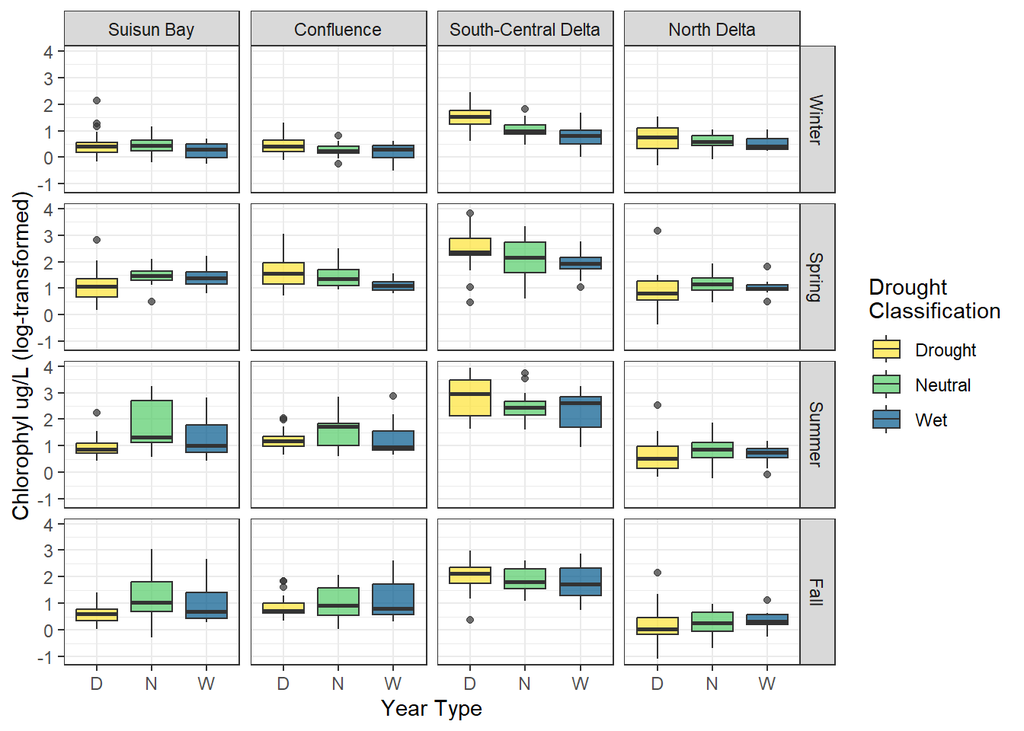

```r
#plot of chlorophyll by drought
ggplot(nutr_chla_data_c, aes(x = Drought, y = Chlorophyll_l, fill = Drought))+
  geom_boxplot(alpha = 0.7)+
  facet_grid(Season~Region)+
 color_pal_drought()+
  ylab("Chlorophyl ug/L (log-transformed)")+
  xlab("Year Type")+
  theme_bw()
```

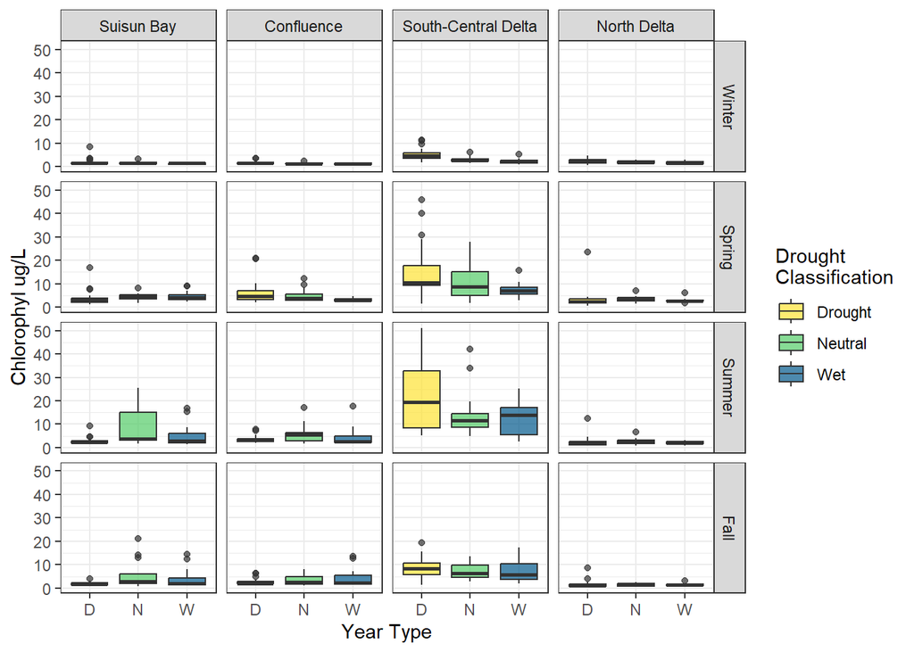

```r
ggplot(nutr_chla_data_c, aes(x = Drought, y = Chlorophyll, fill = Drought))+
  geom_boxplot(alpha = 0.7)+
  facet_grid(Season~Region)+
  color_pal_drought()+
  ylab("Chlorophyl ug/L")+
  xlab("Year Type")+
  theme_bw()
```

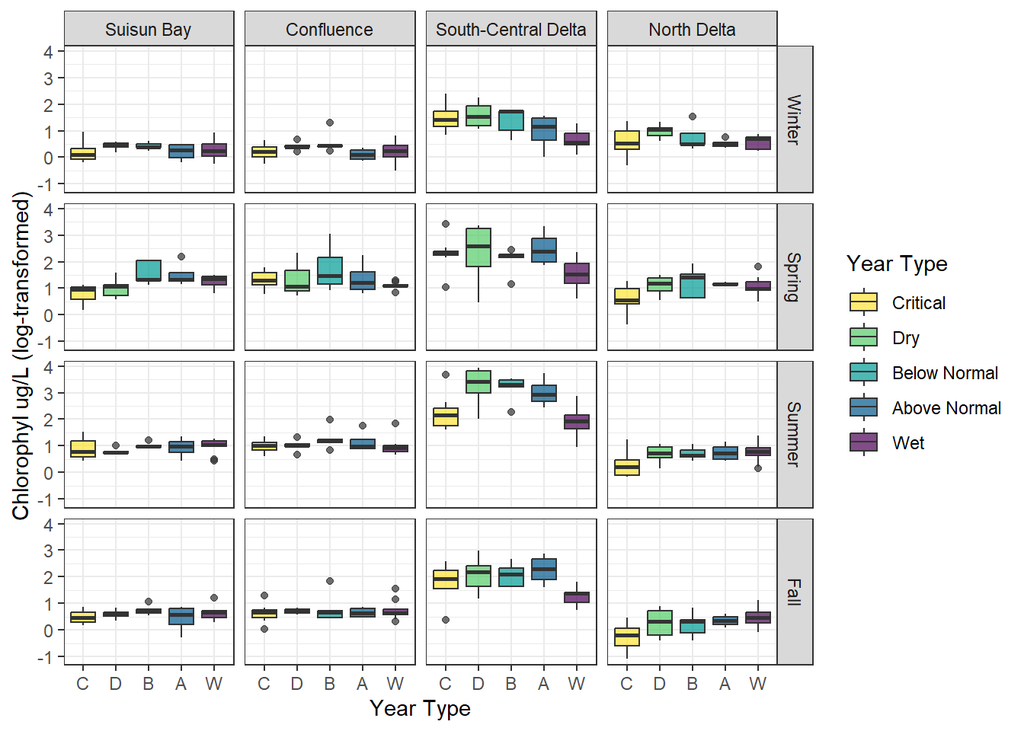

```r
#plot of chlorophyll by water year type - just the more recent years
ggplot(filter(nutr_chla_data_c, YearAdj > 1989), aes(x = YearType, y = Chlorophyll_l, fill = YearType))+
  geom_boxplot(alpha = 0.7)+
  facet_grid(Season~Region)+
  color_pal_yrtype()+
  ylab("Chlorophyl ug/L (log-transformed)")+
  xlab("Year Type")+
  theme_bw()+
  scale_x_discrete(labels = c("C", "D", "B", "A", "W"))
```

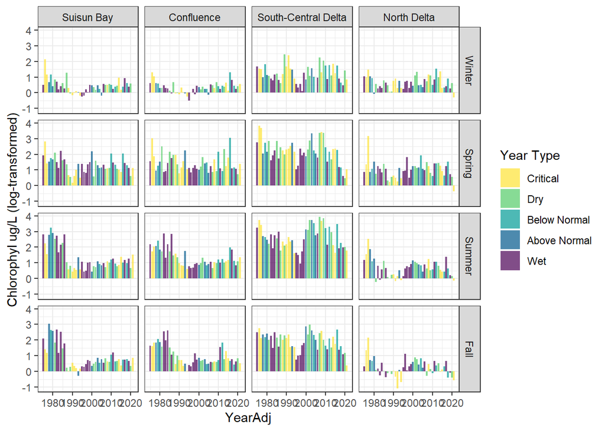

```r
#Bleh, nothing going on there

#plot of chlorophyll by year
ggplot(nutr_chla_data_c, aes(x = YearAdj, y = Chlorophyll_l, fill = YearType))+
  geom_col(alpha = 0.7)+
  facet_grid(Season~Region)+
  color_pal_yrtype()+
  ylab("Chlorophyl ug/L (log-transformed)")+
  theme_bw()
```

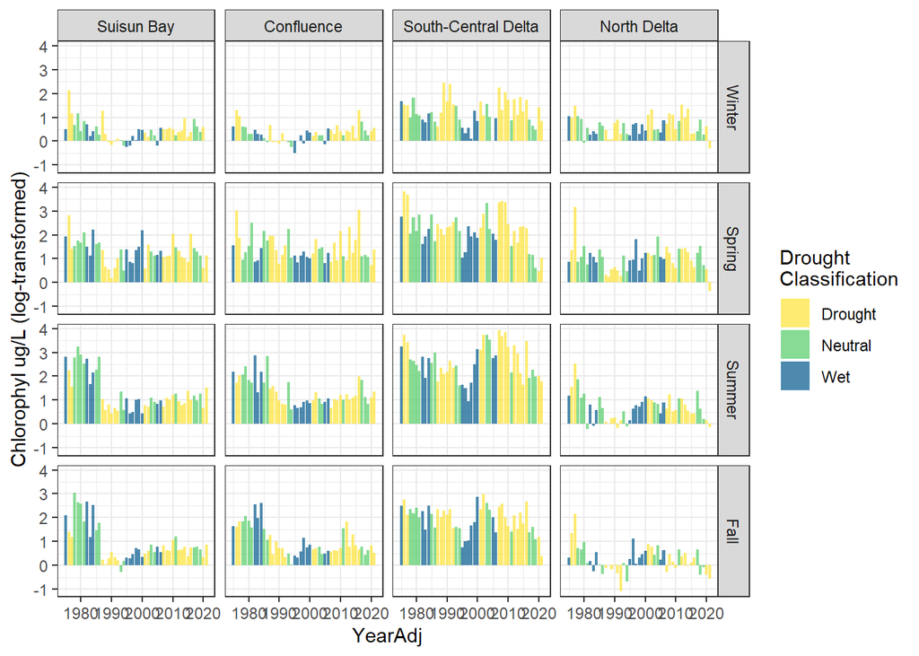

```r
ggplot(nutr_chla_data_c, aes(x = YearAdj, y = Chlorophyll_l, fill = Drought))+
  geom_col(alpha = 0.7)+
  facet_grid(Season~Region)+
  color_pal_drought()+
  ylab("Chlorophyl ug/L (log-transformed)")+
  theme_bw()
```

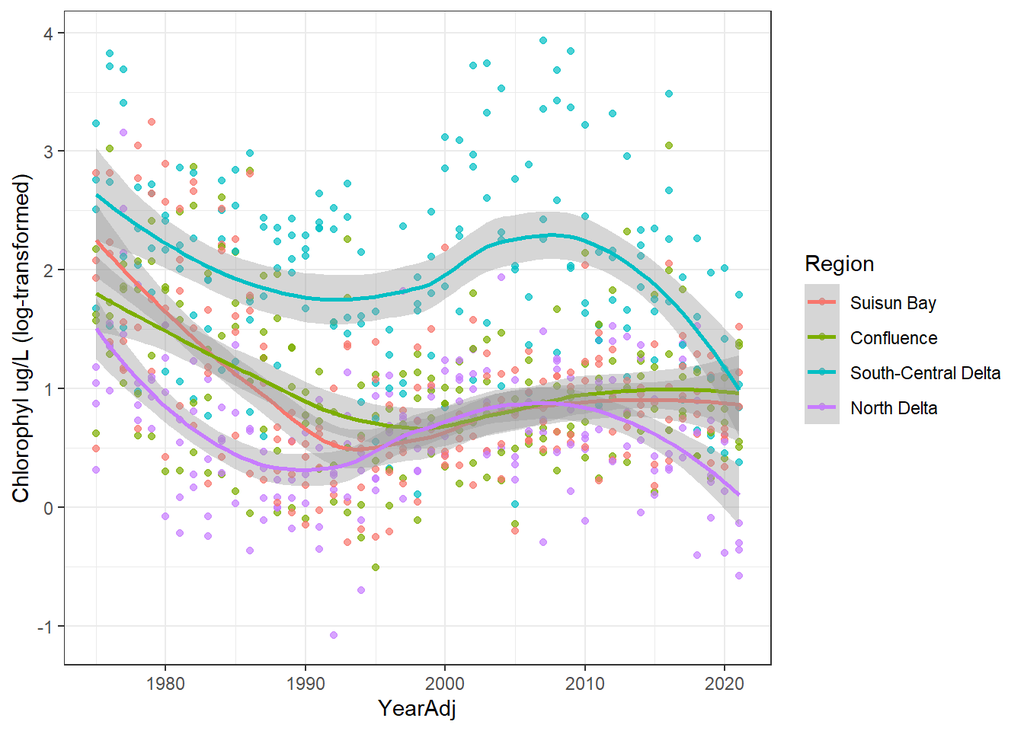

```r
ggplot(nutr_chla_data_c, aes(x = YearAdj, y = Chlorophyll_l, color = Region))+
  geom_point(alpha = 0.7)+
  geom_smooth()+
 # color_pal_drought()+
  ylab("Chlorophyl ug/L (log-transformed)")+
  theme_bw()
```

### Run Model

And now for some statistics

```r
ChlaA <- nutr_chla_data_c %>%
  select(!starts_with(c("DissAmmonia", "DissNitrateNitrite", "DissOrthophos"))) %>%
  drop_na(Chlorophyll_l) %>%
  mutate(
    Regime = case_when(
      YearAdj > 1987 ~ "post-clam",
      YearAdj < 1988 ~ "pre-clam"
    )
  )
```

```r
# model including pre/post clam regime
Chl1 = lm(Chlorophyll_l ~ Drought*Region + Drought*Season + Region*Season + Region*Regime, data = ChlaA)
```

### Check assumptions

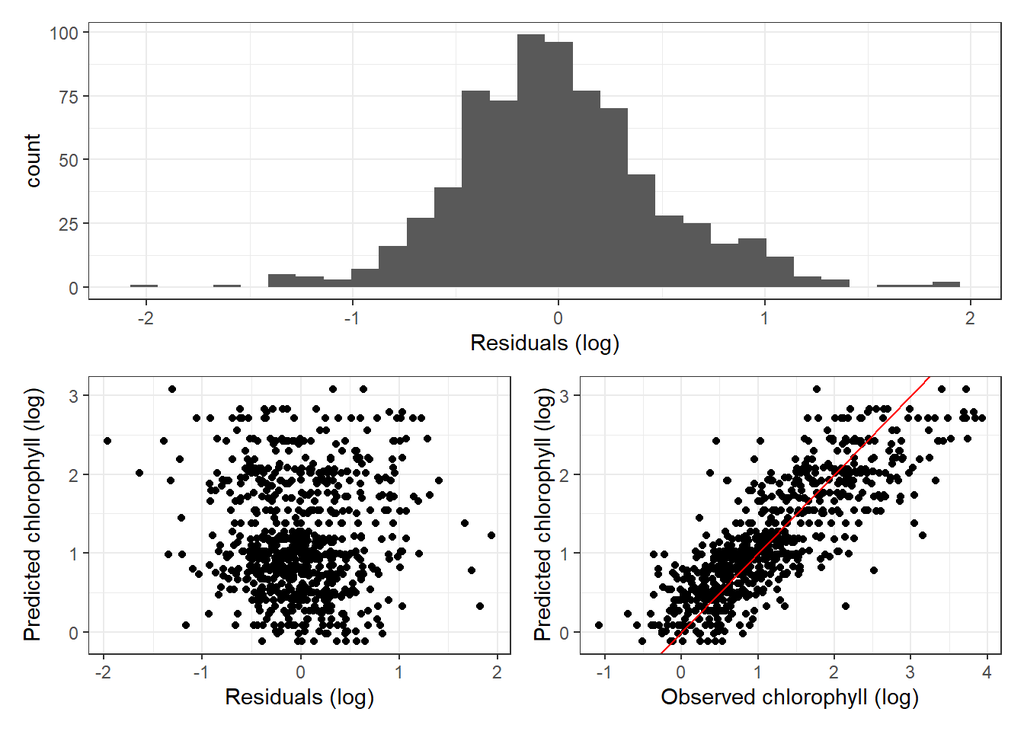

```r
model_plotter(Chl1, ChlaA, "Chlorophyll_l")
```

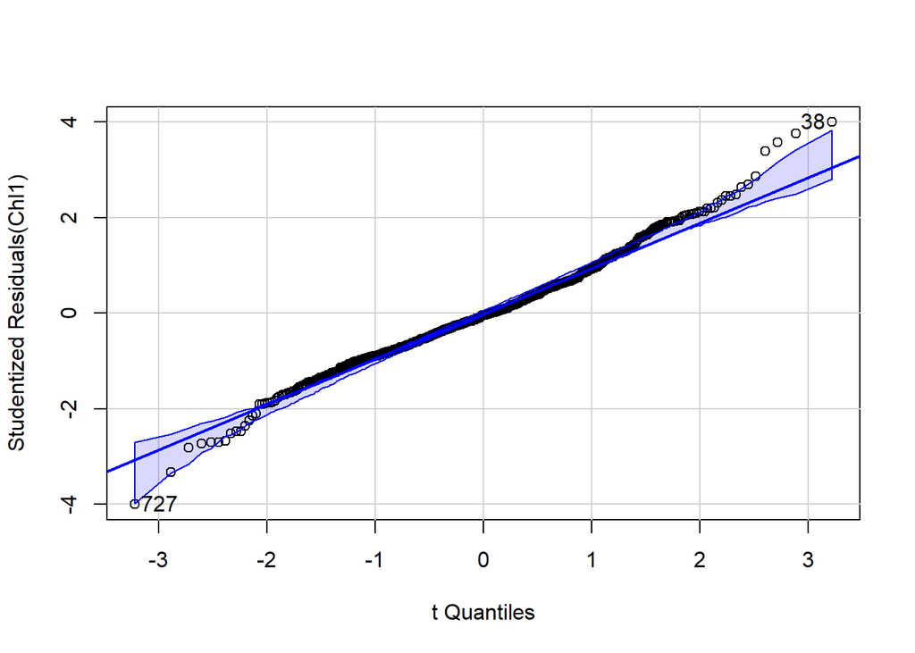

```
## [1]  38 727
```

```r
qqPlot(Chl1)
```

### Check results

```r
summary(Chl1)
```

```
##
## Call:
## lm(formula = Chlorophyll_l ~ Drought * Region + Drought * Season +
##     Region * Season + Region * Regime, data = ChlaA)
##
## Residuals:
##      Min       1Q   Median       3Q      Max
## -1.95802 -0.31743 -0.02147  0.28326  1.93480
##
## Coefficients:
##                                          Estimate Std. Error t value Pr(>|t|)
## (Intercept)                               0.26722    0.09340   2.861 0.004347
## DroughtN                                 -0.10583    0.11769  -0.899 0.368807
## DroughtW                                 -0.25845    0.12182  -2.122 0.034212
## RegionConfluence                          0.13337    0.12076   1.104 0.269783
## RegionSouth-Central Delta                 1.27937    0.12076  10.594  < 2e-16
## RegionNorth Delta                         0.46710    0.12076   3.868 0.000120
## SeasonSpring                              0.75421    0.11948   6.312 4.82e-10
## SeasonSummer                              0.64672    0.11948   5.413 8.48e-08
## SeasonFall                                0.23890    0.11948   1.999 0.045938
## Regimepre-clam                            0.93698    0.08538  10.974  < 2e-16
## DroughtN:RegionConfluence                -0.31701    0.12749  -2.487 0.013124
## DroughtW:RegionConfluence                -0.26037    0.13076  -1.991 0.046831
## DroughtN:RegionSouth-Central Delta       -0.61212    0.12749  -4.801 1.92e-06
## DroughtW:RegionSouth-Central Delta       -0.62607    0.13076  -4.788 2.05e-06
## DroughtN:RegionNorth Delta               -0.15155    0.12749  -1.189 0.234935
## DroughtW:RegionNorth Delta               -0.03289    0.13076  -0.252 0.801467
## DroughtN:SeasonSpring                     0.22364    0.12276   1.822 0.068913
## DroughtW:SeasonSpring                     0.22809    0.12874   1.772 0.076869
## DroughtN:SeasonSummer                     0.46433    0.12276   3.782 0.000168
## DroughtW:SeasonSummer                     0.36279    0.12874   2.818 0.004965
## DroughtN:SeasonFall                       0.40148    0.12276   3.270 0.001125
## DroughtW:SeasonFall                       0.53279    0.12874   4.139 3.91e-05
## RegionConfluence:SeasonSpring             0.22717    0.14701   1.545 0.122729
## RegionSouth-Central Delta:SeasonSpring    0.11638    0.14701   0.792 0.428847
## RegionNorth Delta:SeasonSpring           -0.50248    0.14701  -3.418 0.000667
## RegionConfluence:SeasonSummer             0.12858    0.14701   0.875 0.382091
## RegionSouth-Central Delta:SeasonSummer    0.51493    0.14701   3.503 0.000489
## RegionNorth Delta:SeasonSummer           -0.83737    0.14701  -5.696 1.79e-08
## RegionConfluence:SeasonFall               0.18224    0.14701   1.240 0.215514
```

[output cut: 31 more lines]

```
## RegionConfluence:SeasonSummer
## RegionSouth-Central Delta:SeasonSummer   ***
## RegionNorth Delta:SeasonSummer           ***
## RegionConfluence:SeasonFall
## RegionSouth-Central Delta:SeasonFall
## RegionNorth Delta:SeasonFall             ***
## RegionConfluence:Regimepre-clam          .
## RegionSouth-Central Delta:Regimepre-clam ***
## RegionNorth Delta:Regimepre-clam         ***
## ---
## Signif. codes:  0 '***' 0.001 '**' 0.01 '*' 0.05 '.' 0.1 ' ' 1
##
## Residual standard error: 0.5026 on 717 degrees of freedom
## Multiple R-squared:  0.6796, Adjusted R-squared:  0.6648
## F-statistic: 46.08 on 33 and 717 DF,  p-value: < 2.2e-16
```

```r
Ch1_Anova<-Anova(Chl1, type=3, contrasts=list(topic=contr.sum, sys=contr.sum))
Ch1_Anova
```

```
## Anova Table (Type III tests)
##
## Response: Chlorophyll_l
##                 Sum Sq  Df  F value    Pr(>F)
## (Intercept)      2.067   1   8.1848 0.0043472 **
## Drought          1.138   2   2.2519 0.1059389
## Region          34.549   3  45.5978 < 2.2e-16 ***
## Season          13.177   3  17.3915 6.571e-11 ***
## Regime          30.416   1 120.4313 < 2.2e-16 ***
## Drought:Region   9.933   6   6.5551 9.399e-07 ***
## Drought:Season   6.877   6   4.5384 0.0001578 ***
## Region:Season   30.337   9  13.3465 < 2.2e-16 ***
## Region:Regime   10.462   3  13.8075 9.212e-09 ***
## Residuals      181.086 717
## ---
## Signif. codes:  0 '***' 0.001 '**' 0.01 '*' 0.05 '.' 0.1 ' ' 1
```

```r
# visreg(Chl1, xvar = "Drought", by = "Region")
# visreg(Chl1, xvar = "Drought", by = "Season")
# visreg(Chl1, xvar = "Region", by = "Season")

# pairsC =  emmeans(Chl1, pairwise ~ Drought*Region)
# plot(pairsC, comparisons = T)
# pairsC2 =  emmeans(Chl1, pairwise ~ Drought*Season)
# plot(pairsC2, comparisons = T)
#
# pairsC3 =  emmeans(Chl1, pairwise ~Regime*Region)
# plot(pairsC3, comparisons = T)
```

### Partial R<sup>2</sup>

How much variability is explained by the Drought index?

```r
partial.r2(Ch1_Anova)
```

```
## [1] 0.09017665
```

### Post-hoc tests and figures

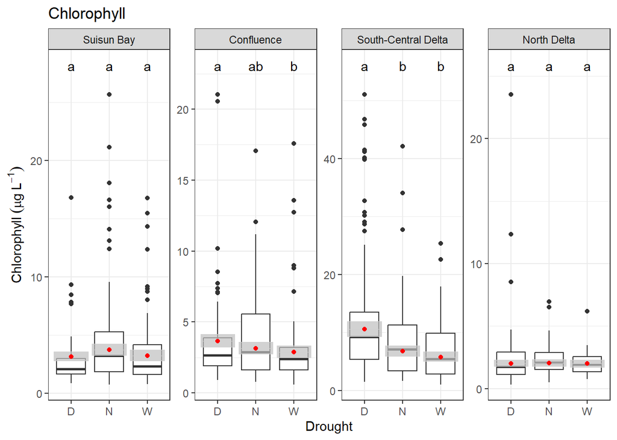

```r
ChRegion = pub_figure_plotter(ChlaA, Chlorophyll, expression(Chlorophyll~(mu*g~L^{-1})), Region, Chl1, log_trans = T, plt_title = "Chlorophyll")
```

```r
ChRegion$diffs
```

```
## # A tibble: 4 × 4
##   Region                  D     W difference
##   <fct>               <dbl> <dbl>      <dbl>
## 1 Suisun Bay           3.14  3.22    -0.0715
## 2 Confluence           3.65  2.88     0.773
## 3 South-Central Delta 10.6   5.77     4.79
## 4 North Delta          2.03  2.01     0.0210
```

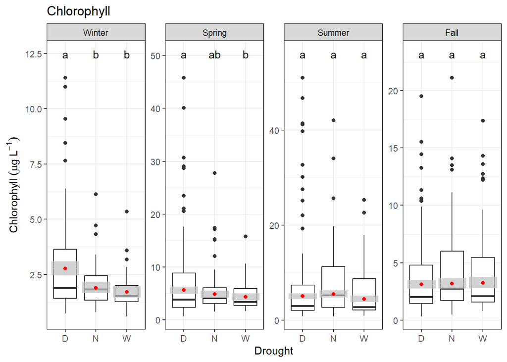

```r
CHSeason = pub_figure_plotter(ChlaA, Chlorophyll, expression(Chlorophyll~(mu*g~L^{-1})), Season, Chl1, log_trans = T, plt_title = "Chlorophyll")
```

```r
CHSeason$diffs
```

```
## # A tibble: 4 × 4
##   Season     D     W difference
##   <fct>  <dbl> <dbl>      <dbl>
## 1 Winter  2.77  1.70      1.07
## 2 Spring  5.65  4.36      1.30
## 3 Summer  5.03  4.44      0.594
## 4 Fall    3.12  3.26     -0.142
```

```r
# Run Post-hoc test for Regime by region
emRegime = emmeans(Chl1, pairwise ~ Regime|Region)

# Calculate effect sizes and match up p-values
emRegime_diff = as_tibble(emRegime$emmeans) %>%
  mutate(trans = exp(emmean)) %>%
  select(Regime, Region, trans) %>%
  pivot_wider(names_from = Regime, values_from = trans) %>%
  mutate(difference = `post-clam` - `pre-clam`) %>%
  left_join(as_tibble(emRegime$contrasts) %>% select(Region, p.value))

emRegime_diff
```

```
## # A tibble: 4 × 5
##   Region              `post-clam` `pre-clam` difference  p.value
##   <fct>                     <dbl>      <dbl>      <dbl>    <dbl>
## 1 Suisun Bay                 2.10       5.35     -3.25  5.22e-26
## 2 Confluence                 2.26       4.56     -2.30  1.03e-15
## 3 South-Central Delta        6.18       8.96     -2.78  1.54e- 5
## 4 North Delta                1.80       2.28     -0.482 5.66e- 3
```

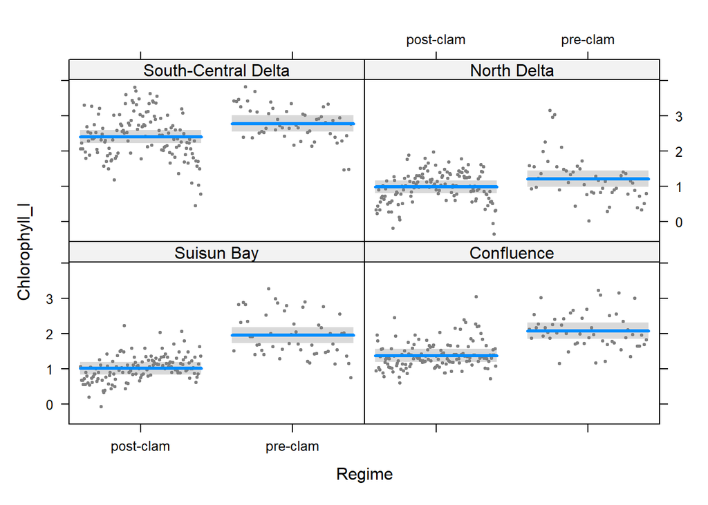

```r
visreg(Chl1, xvar = "Regime", by = "Region")
```

Well, I added the regime shift at the clam invasion and now my diagnostic plots look better, droughts definitely have higher chlorophyll in the south-central region, and definitely have higher winter and spring chlorophyll YAY!!

### Run Alternate Models

Try the linear model with Sac valley index. We didn’t use this for the manuscript.

```r
Chl2 = lm(Chlorophyll_l ~ SVIndex*Region + SVIndex*Season + Region*Season + Region*Regime, data = ChlaA)
summary(Chl2)
```

```
##
## Call:
## lm(formula = Chlorophyll_l ~ SVIndex * Region + SVIndex * Season +
##     Region * Season + Region * Regime, data = ChlaA)
##
## Residuals:
##      Min       1Q   Median       3Q      Max
## -1.83126 -0.31906 -0.04021  0.28741  1.89132
##
## Coefficients:
##                                          Estimate Std. Error t value Pr(>|t|)
## (Intercept)                               0.29957    0.14977   2.000 0.045861
## SVIndex                                  -0.01783    0.01649  -1.081 0.279921
## RegionConfluence                          0.21763    0.17316   1.257 0.209228
## RegionSouth-Central Delta                 1.72978    0.17316   9.989  < 2e-16
## RegionNorth Delta                         0.51365    0.17316   2.966 0.003114
## SeasonSpring                              0.76352    0.17236   4.430 1.09e-05
## SeasonSummer                              0.49602    0.17236   2.878 0.004122
## SeasonFall                                0.03521    0.17236   0.204 0.838177
## Regimepre-clam                            0.96605    0.08336  11.589  < 2e-16
## SVIndex:RegionConfluence                 -0.02904    0.01758  -1.651 0.099083
## SVIndex:RegionSouth-Central Delta        -0.09812    0.01758  -5.580 3.41e-08
## SVIndex:RegionNorth Delta                -0.01180    0.01758  -0.671 0.502354
## SVIndex:SeasonSpring                      0.01496    0.01746   0.857 0.391933
## SVIndex:SeasonSummer                      0.04918    0.01746   2.817 0.004984
## SVIndex:SeasonFall                        0.05917    0.01746   3.389 0.000740
## RegionConfluence:SeasonSpring             0.22642    0.14839   1.526 0.127487
## RegionSouth-Central Delta:SeasonSpring    0.11562    0.14839   0.779 0.436118
## RegionNorth Delta:SeasonSpring           -0.50324    0.14839  -3.391 0.000733
## RegionConfluence:SeasonSummer             0.12782    0.14839   0.861 0.389303
## RegionSouth-Central Delta:SeasonSummer    0.51417    0.14839   3.465 0.000561
## RegionNorth Delta:SeasonSummer           -0.83812    0.14839  -5.648 2.33e-08
## RegionConfluence:SeasonFall               0.18149    0.14839   1.223 0.221701
## RegionSouth-Central Delta:SeasonFall      0.22683    0.14839   1.529 0.126787
## RegionNorth Delta:SeasonFall             -0.88648    0.14839  -5.974 3.63e-09
## RegionConfluence:Regimepre-clam          -0.30359    0.11785  -2.576 0.010192
## RegionSouth-Central Delta:Regimepre-clam -0.67036    0.11785  -5.688 1.86e-08
## RegionNorth Delta:Regimepre-clam         -0.72751    0.11785  -6.173 1.11e-09
##
## (Intercept)                              *
```

[output cut: 17 more lines]

```
## RegionConfluence:SeasonSummer
## RegionSouth-Central Delta:SeasonSummer   ***
## RegionNorth Delta:SeasonSummer           ***
## RegionConfluence:SeasonFall
## RegionSouth-Central Delta:SeasonFall
## RegionNorth Delta:SeasonFall             ***
## RegionConfluence:Regimepre-clam          *
## RegionSouth-Central Delta:Regimepre-clam ***
## RegionNorth Delta:Regimepre-clam         ***
## ---
## Signif. codes:  0 '***' 0.001 '**' 0.01 '*' 0.05 '.' 0.1 ' ' 1
##
## Residual standard error: 0.5072 on 724 degrees of freedom
## Multiple R-squared:  0.6704, Adjusted R-squared:  0.6585
## F-statistic: 56.63 on 26 and 724 DF,  p-value: < 2.2e-16
```

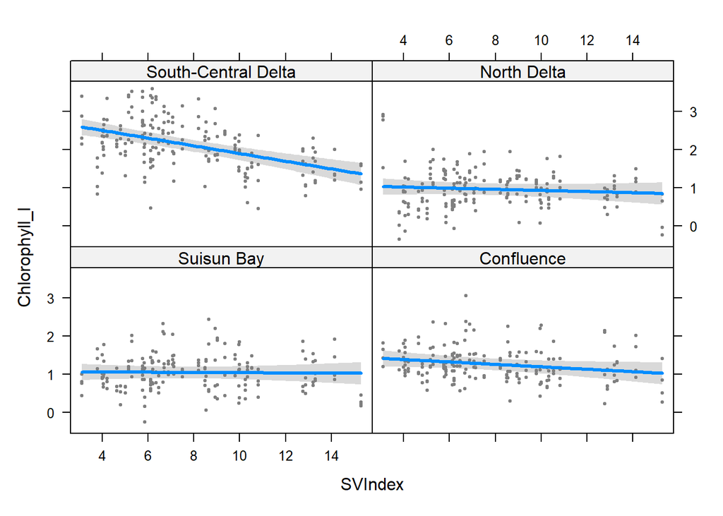

```r
# plot(Chl2)

visreg(Chl2, xvar ="SVIndex", by = "Region")
```

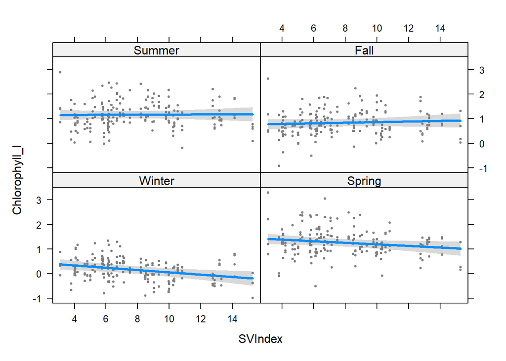

```r
visreg(Chl2, xvar = "SVIndex", by = "Season")
```

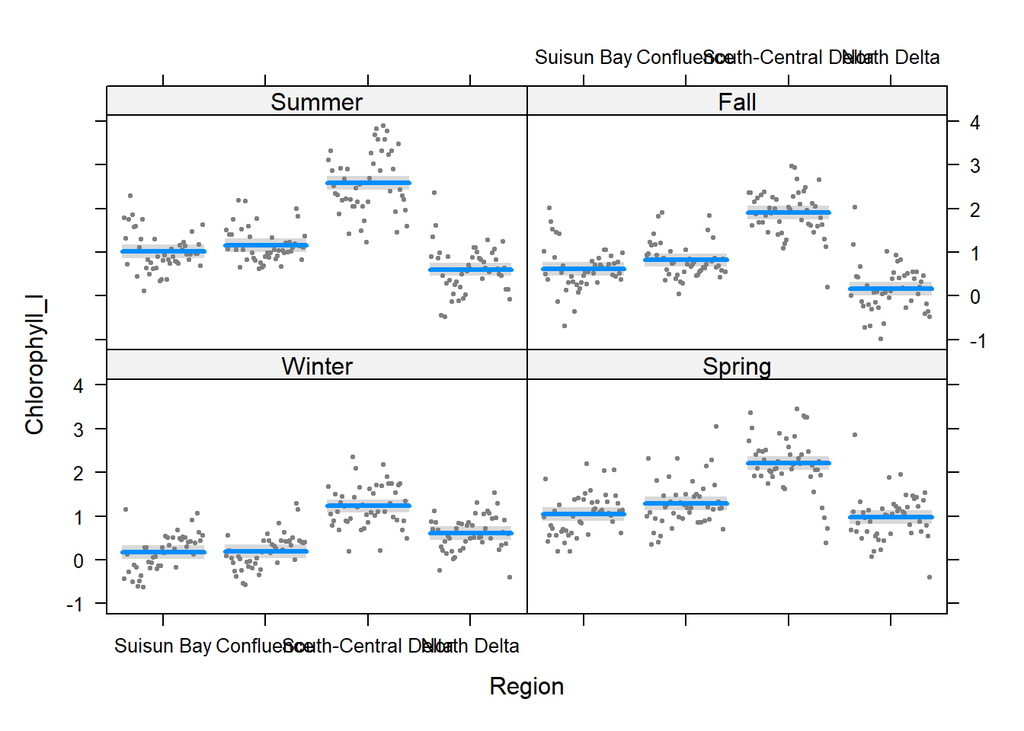

```r
visreg(Chl2, xvar = "Region", by = "Season")
```

The rest of this was an attempt to use Bayesian stats but I decided not to go there after all.

```r
library(brms)

chlb = brm(Chlorophyll ~ Region*Drought+ Season*Drought + Region*Season, data = ChlaA,
           family = lognormal, backend = "cmdstanr", silent = 2)
summary(chlb)
pp_check(chlb)
cex = conditional_effects(chlb, ask = FALSE)
cex
```

## Save all model outputs

```r
# Define file paths for output and figures for the manuscript
fp_output <- here("results/tables")
fp_plots <- here("results/figures")
```

### Anovas

```r
anovas <-
  bind_rows(
    mutate(as_tibble(Aman, rownames = "Parameter"), Model = "Ammonium"),
    mutate(as_tibble(NatAn, rownames = "Parameter"), Model = "Nitrate + Nitrite"),
    mutate(as_tibble(Panova, rownames = "Parameter"), Model = "Ortho-phosphate"),
    mutate(as_tibble(Ch1_Anova, rownames = "Parameter"), Model = "Chlorophyll")
  ) %>%
  mutate(
    `Pr(>F)` = if_else(
      `Pr(>F)` < 0.001,
      "< 0.001",
      as.character(formatC(signif(`Pr(>F)`, 4), digits = 4, format = "fg", flag = "#"))
    ),
    across(c(`Sum Sq`, `F value`), ~formatC(signif(.x, 4), digits = 4, format = "fg", flag = "#"))
  ) %>%
  relocate(Model)

kbl(anovas) %>% kable_styling(fixed_thead = TRUE)
```

Model

Parameter

Sum Sq

Df

F value

Pr(>F)

Ammonium

(Intercept)

74.97

1

502.8

< 0.001

Ammonium

Drought

1.779

2

5.968

0.002700

Ammonium

Region

1.656

3

3.702

0.01160

Ammonium

Season

23.03

3

51.48

< 0.001

Ammonium

StocktonUpgrade

0.8526

1

5.719

0.01706

Ammonium

Drought:Region

9.670

6

10.81

< 0.001

Ammonium

Drought:Season

7.447

6

8.325

< 0.001

Ammonium

Region:Season

46.16

9

34.40

< 0.001

Ammonium

Region:StocktonUpgrade

22.85

3

51.09

< 0.001

Ammonium

Residuals

98.55

661

NA

NA

Nitrate + Nitrite

(Intercept)

16.83

1

196.2

< 0.001

Nitrate + Nitrite

Drought

1.099

2

6.409

0.001742

Nitrate + Nitrite

Region

40.84

3

158.7

< 0.001

Nitrate + Nitrite

Season

1.315

3

5.112

0.001665

Nitrate + Nitrite

Drought:Region

3.374

6

6.557

< 0.001

Nitrate + Nitrite

Drought:Season

2.380

6

4.626

< 0.001

Nitrate + Nitrite

Region:Season

6.875

9

8.906

< 0.001

Nitrate + Nitrite

Residuals

61.58

718

NA

NA

Ortho-phosphate

(Intercept)

< 0.001

Ortho-phosphate

Drought

1.298

2

6.968

0.001007

Ortho-phosphate

Region

11.07

3

39.60

< 0.001

Ortho-phosphate

Season

2.329

3

8.333

< 0.001

Ortho-phosphate

Drought:Region

1.814

6

3.246

0.003731

Ortho-phosphate

Drought:Season

1.550

6

2.773

0.01132

Ortho-phosphate

Region:Season

7.531

9

8.983

< 0.001

Ortho-phosphate

Residuals

67.07

720

NA

NA

Chlorophyll

(Intercept)

2.067

1

8.185

0.004347

Chlorophyll

Drought

1.138

2

2.252

0.1059

Chlorophyll

Region

34.55

3

45.60

< 0.001

Chlorophyll

Season

13.18

3

17.39

< 0.001

Chlorophyll

Regime

30.42

1

120.4

< 0.001

Chlorophyll

Drought:Region

9.933

6

6.555

< 0.001

Chlorophyll

Drought:Season

6.877

6

4.538

< 0.001

Chlorophyll

Region:Season

30.34

9

13.35

< 0.001

Chlorophyll

Region:Regime

10.46

3

13.81

< 0.001

Chlorophyll

Residuals

181.1

717

NA

NA

```r
# Excel is the worst, I had to add letters to these numbers so it wouldn't re-round them
anovas %>%
  mutate(
    across(
      c(`Sum Sq`, `F value`, `Pr(>F)`),
      ~paste0(ifelse(str_detect(.x, fixed("NA")) | is.na(.x), "", .x), "ZZZ")
    )
  ) %>%
  write_csv(file.path(fp_output, "Nutr_Chla_anovas.csv"))
```

### Post-hoc tests

```r
tukeys <-
  bind_rows(
    mutate(AmRegions$contrasts, Model = "Ammonium", `Contrast type` = "region"),
    mutate(AmSeasons$contrasts, Model = "Ammonium", `Contrast type` = "season"),
    mutate(NNRegion$contrasts, Model = "Nitrate + Nitrite", `Contrast type` = "region"),
    mutate(NNSeason$contrasts, Model = "Nitrate + Nitrite", `Contrast type` = "season"),
    mutate(OPRegion$contrasts, Model = "Ortho-phosphate", `Contrast type` = "region"),
    mutate(OPSeason$contrasts, Model = "Ortho-phosphate", `Contrast type` = "season"),
    mutate(ChRegion$contrasts, Model = "Chlorophyll", `Contrast type` = "region"),
    mutate(CHSeason$contrasts, Model = "Chlorophyll", `Contrast type` = "season")
  ) %>%
  rename(
    `p-value` = p.value,
    `t-ratio` = t.ratio
  ) %>%
  mutate(
    `p-value` = if_else(
      `p-value` < 0.001,
      "< 0.001",
      as.character(formatC(signif(`p-value`, 4), digits = 4, format = "fg", flag = "#"))
    ),
    Group = if_else(is.na(Region), as.character(Season), as.character(Region)),
    across(c(estimate, SE, `t-ratio`), ~formatC(signif(.x, 4), digits = 4, format = "fg", flag = "#"))
  ) %>%
  select(
    Model,
    `Contrast type`,
    Group,
    Contrast = contrast,
    Estimate = estimate,
    SE,
    DF = df,
    `t-ratio`,
    `p-value`
  )

kbl(tukeys) %>% kable_styling(fixed_thead = TRUE)
```

| Model | Contrast type | Group | Contrast | Estimate | SE | DF | t-ratio | p-value |
| --- | --- | --- | --- | --- | --- | --- | --- | --- |
| Ammonium | region | Suisun Bay | D - N | 0.1594 | 0.06957 | 661 | 2.290 | 0.05783 |
| Ammonium | region | Suisun Bay | D - W | 0.2000 | 0.07670 | 661 | 2.607 | 0.02527 |
| Ammonium | region | Suisun Bay | N - W | 0.04061 | 0.07791 | 661 | 0.5212 | 0.8610 |
| Ammonium | region | Confluence | D - N | 0.09564 | 0.06987 | 661 | 1.369 | 0.3580 |
| Ammonium | region | Confluence | D - W | 0.1974 | 0.07671 | 661 | 2.573 | 0.02774 |
| Ammonium | region | Confluence | N - W | 0.1017 | 0.07829 | 661 | 1.300 | 0.3959 |
| Ammonium | region | South-Central Delta | D - N | 0.1261 | 0.07225 | 661 | 1.746 | 0.1891 |
| Ammonium | region | South-Central Delta | D - W | 0.006499 | 0.08031 | 661 | 0.08093 | 0.9964 |
| Ammonium | region | South-Central Delta | N - W | -0.1196 | 0.08044 | 661 | -1.487 | 0.2978 |
| Ammonium | region | North Delta | D - N | 0.3639 | 0.07225 | 661 | 5.037 | < 0.001 |
| Ammonium | region | North Delta | D - W | 0.8457 | 0.08031 | 661 | 10.53 | < 0.001 |
| Ammonium | region | North Delta | N - W | 0.4817 | 0.08044 | 661 | 5.988 | < 0.001 |
| Ammonium | season | Winter | D - N | 0.1491 | 0.07006 | 661 | 2.128 | 0.08492 |
| Ammonium | season | Winter | D - W | 0.4564 | 0.07456 | 661 | 6.121 | < 0.001 |
| Ammonium | season | Winter | N - W | 0.3073 | 0.07781 | 661 | 3.949 | < 0.001 |
| Ammonium | season | Spring | D - N | 0.4229 | 0.06954 | 661 | 6.081 | < 0.001 |
| Ammonium | season | Spring | D - W | 0.6261 | 0.07364 | 661 | 8.502 | < 0.001 |
| Ammonium | season | Spring | N - W | 0.2032 | 0.07816 | 661 | 2.600 | 0.02576 |
| Ammonium | season | Summer | D - N | 0.1227 | 0.06954 | 661 | 1.764 | 0.1824 |
| Ammonium | season | Summer | D - W | 0.04805 | 0.07462 | 661 | 0.6440 | 0.7958 |
| Ammonium | season | Summer | N - W | -0.07465 | 0.07908 | 661 | -0.9440 | 0.6126 |
| Ammonium | season | Fall | D - N | 0.05035 | 0.06954 | 661 | 0.7240 | 0.7494 |
| Ammonium | season | Fall | D - W | 0.1189 | 0.07364 | 661 | 1.615 | 0.2401 |
| Ammonium | season | Fall | N - W | 0.06857 | 0.07816 | 661 | 0.8773 | 0.6548 |
| Nitrate + Nitrite | region | Suisun Bay | D - N | 0.3404 | 0.05065 | 718 | 6.721 | < 0.001 |
| Nitrate + Nitrite | region | Suisun Bay | D - W | 0.3864 | 0.05311 | 718 | 7.275 | < 0.001 |
| Nitrate + Nitrite | region | Suisun Bay | N - W | 0.04596 | 0.05761 | 718 | 0.7978 | 0.7045 |
| Nitrate + Nitrite | region | Confluence | D - N | 0.2665 | 0.05065 | 718 | 5.262 | < 0.001 |
| Nitrate + Nitrite | region | Confluence | D - W | 0.3753 | 0.05311 | 718 | 7.066 | < 0.001 |
| Nitrate + Nitrite | region | Confluence | N - W | 0.1087 | 0.05761 | 718 | 1.888 | 0.1429 |

[output cut: 66 more lines]

```r
# Excel is the worst, I had to add letters to these numbers so it wouldn't re-round them
tukeys %>%
  mutate(
    across(
      c(Estimate, SE, `t-ratio`, `p-value`),
      ~paste0(ifelse(str_detect(.x, fixed("NA")) | is.na(.x), "", .x), "ZZZ")
    )
  ) %>%
  write_csv(file.path(fp_output, "Nutr_Chla_tukeys.csv"))
```

### Manuscript Figures

Combine all figures of model results for the nutrient and chlorophyll parameters into larger figures for the manuscript, one for the regional analyses and one for the seasonal analyses.

```r
# Region plots
plt_nutr_chla_region <- comb_pub_figs(list(AmRegions$plt, NNRegion$plt, OPRegion$plt, ChRegion$plt))

ggsave(
  file.path(fp_plots, "nutr_chla_region.jpg"),
  plot = plt_nutr_chla_region,
  width = 8,
  height = 11,
  units = "in",
  dpi = 300
)

# Season plots
plt_nutr_chla_season <- comb_pub_figs(list(AmSeasons$plt, NNSeason$plt, OPSeason$plt, CHSeason$plt))

ggsave(
  file.path(fp_plots, "nutr_chla_season.jpg"),
  plot = plt_nutr_chla_season,
  width = 8,
  height = 11,
  units = "in",
  dpi = 300
)
```